# Coursera Practical Machine Learning Course Project

DP

Wednesday, January 21, 2015

### Overview

This R markdown file has been prepared to satisfy the requirements for the Coursera Practical Machine Learning course.

The objective of this assignment is to take data collected from “fitbit” type devices, and use it to predict the manner in which the exercise was performed.

This report will outline 1) the steps taken in constructin the model, including data cleansing, exploration, and model selection; 2) use of cross validation, and 3) estimates of in sample/out of sample error.

Data was kindly provided by the group at this source: : http://groupware.les.inf.puc-rio.br/har . source: Ugulino, W.; Cardador, D.; Vega, K.; Velloso, E.; Milidiu, R.; Fuks, H. Wearable Computing: Accelerometers’ Data Classification of Body Postures and Movements .

## Data Preparation and Cleansing

1st step is to load in the appropriate packages, as well as the source data.

```r
##load in packages
suppressWarnings(library("caret"))
```

```r
suppressWarnings(library("corrplot"))
suppressWarnings(library("ggplot2"))

##set wd
setwd("C:/Users/dp/Documents/coursera/MachineLearning/courseproject/github project")

## read in data
pmlData <- read.csv("pml-training.csv", na.strings=c("#DIV/0!"))
pmlTestingData <- read.csv("pml-testing.csv", na.strings=c("#DIV/0!"))
```

## data cleansing

The steps taken to clean up the data include: 1. perform str of the data to understand type 2. removing columns 1-7, which are not predictors 3. removing columns with many NAs (these are summary variable columns) 4. understand the mix between the classe variable

```r
str(pmlData)
```

```
## 'data.frame':    19622 obs. of  160 variables:
##  $ X                       : int  1 2 3 4 5 6 7 8 9 10 ...
##  $ user_name               : Factor w/ 6 levels "adelmo","carlitos",..: 2 2 2 2 2 2 2 2 2 2 ...
##  $ raw_timestamp_part_1    : int  1323084231 1323084231 1323084231 1323084232 1323084232 1323084232 1323084232 1323084232 1323084232 1323084232 ...
##  $ raw_timestamp_part_2    : int  788290 808298 820366 120339 196328 304277 368296 440390 484323 484434 ...
##  $ cvtd_timestamp          : Factor w/ 20 levels "02/12/2011 13:32",..: 9 9 9 9 9 9 9 9 9 9 ...
##  $ new_window              : Factor w/ 2 levels "no","yes": 1 1 1 1 1 1 1 1 1 1 ...
##  $ num_window              : int  11 11 11 12 12 12 12 12 12 12 ...
##  $ roll_belt               : num  1.41 1.41 1.42 1.48 1.48 1.45 1.42 1.42 1.43 1.45 ...
##  $ pitch_belt              : num  8.07 8.07 8.07 8.05 8.07 8.06 8.09 8.13 8.16 8.17 ...
##  $ yaw_belt                : num  -94.4 -94.4 -94.4 -94.4 -94.4 -94.4 -94.4 -94.4 -94.4 -94.4 ...
##  $ total_accel_belt        : int  3 3 3 3 3 3 3 3 3 3 ...
##  $ kurtosis_roll_belt      : num  NA NA NA NA NA NA NA NA NA NA ...
##  $ kurtosis_picth_belt     : num  NA NA NA NA NA NA NA NA NA NA ...
##  $ kurtosis_yaw_belt       : logi  NA NA NA NA NA NA ...
```

[output cut: 86 more lines]

```r
pmlData <- pmlData[,-c(1:7)]
pmlData <- pmlData[,-grep("var_|kurtosis_|max_|min_|avg_|stddev_|amplitude_|total_|skewness_", names(pmlData))]
prop.table(table(pmlData$classe))
```

```
##
##         A         B         C         D         E
## 0.2843747 0.1935073 0.1743961 0.1638977 0.1838243
```

## Creating Training and Cross Validation Sets

Here I split the overall dataset into a training set and a cross validation set, using a 80/20 proportion.

```r
inTrain <- createDataPartition(y=pmlData$classe, p=.8, list=F)
training <- pmlData[inTrain,]
cvalidation <- pmlData[-inTrain,]

## compare the proportion of observations within each class for both sets
rbind(prop.table(table(training$classe)),prop.table(table(cvalidation$classe)))
```

```
##              A         B         C         D         E
## [1,] 0.2843493 0.1935155 0.1744060 0.1638958 0.1838334
## [2,] 0.2844762 0.1934744 0.1743564 0.1639052 0.1837879
```

## Tidying Data Set

The next step was to look for zero/near-zero variance variables, however, none were found.

The following step was to look for highly correlated variables:

```r
## look for zero variance, or near zero variance
nsv <- nearZeroVar(training, saveMetrics=T)
nsv$zeroVar
```

```
##  [1] FALSE FALSE FALSE FALSE FALSE FALSE FALSE FALSE FALSE FALSE FALSE
## [12] FALSE FALSE FALSE FALSE FALSE FALSE FALSE FALSE FALSE FALSE FALSE
## [23] FALSE FALSE FALSE FALSE FALSE FALSE FALSE FALSE FALSE FALSE FALSE
## [34] FALSE FALSE FALSE FALSE FALSE FALSE FALSE FALSE FALSE FALSE FALSE
## [45] FALSE FALSE FALSE FALSE FALSE
```

```r
nsv$nzv
```

```
##  [1] FALSE FALSE FALSE FALSE FALSE FALSE FALSE FALSE FALSE FALSE FALSE
## [12] FALSE FALSE FALSE FALSE FALSE FALSE FALSE FALSE FALSE FALSE FALSE
## [23] FALSE FALSE FALSE FALSE FALSE FALSE FALSE FALSE FALSE FALSE FALSE
## [34] FALSE FALSE FALSE FALSE FALSE FALSE FALSE FALSE FALSE FALSE FALSE
## [45] FALSE FALSE FALSE FALSE FALSE
```

```r
## looking for highly correlated features
corrCheck <- cor(subset(training, select=-classe))
highCorr <- findCorrelation(corrCheck, cutoff=.95)
names(training[,highCorr])
```

```
## [1] "accel_belt_z"     "accel_belt_x"     "gyros_dumbbell_x"
```

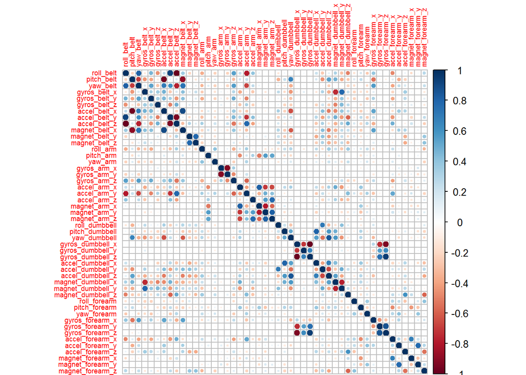

```r
corrplot(corrCheck, tl.cex=.55)
```

## model Creation

Using the caret package, I selected to use a randomforest model. Due to processing constraints, I only used 2 bootstraps.

```r
modFit <- train(classe ~., data=training, method="rf", trControl=trainControl(number=2,classProbs=T))
modFit
```

```
## Random Forest
##
## 15699 samples
##    48 predictor
##     5 classes: 'A', 'B', 'C', 'D', 'E'
##
## No pre-processing
## Resampling: Bootstrapped (2 reps)
##
## Summary of sample sizes: 15699, 15699
##
## Resampling results across tuning parameters:
##
##   mtry  Accuracy   Kappa      Accuracy SD  Kappa SD
##    2    0.9912431  0.9889275  0.000374280  0.0004791985
##   25    0.9902911  0.9877254  0.004161685  0.0052563295
##   48    0.9793658  0.9739142  0.001210946  0.0015174240
##
## Accuracy was used to select the optimal model using  the largest value.
## The final value used for the model was mtry = 2.
```

Based on the high accuracy, I decided to stick with this model and run a prediction with both the training set and the validation data sets.

```r
##training set
pred <- predict(modFit, training)
confusionMatrix(pred, training$classe)
```

```
## Confusion Matrix and Statistics
##
##           Reference
## Prediction    A    B    C    D    E
##          A 4464    0    0    0    0
##          B    0 3038    0    0    0
##          C    0    0 2738    0    0
##          D    0    0    0 2573    0
##          E    0    0    0    0 2886
##
## Overall Statistics
##
##                Accuracy : 1
##                  95% CI : (0.9998, 1)
##     No Information Rate : 0.2843
##     P-Value [Acc > NIR] : < 2.2e-16
##
##                   Kappa : 1
##  Mcnemar's Test P-Value : NA
##
## Statistics by Class:
##
##                      Class: A Class: B Class: C Class: D Class: E
## Sensitivity            1.0000   1.0000   1.0000   1.0000   1.0000
## Specificity            1.0000   1.0000   1.0000   1.0000   1.0000
## Pos Pred Value         1.0000   1.0000   1.0000   1.0000   1.0000
## Neg Pred Value         1.0000   1.0000   1.0000   1.0000   1.0000
## Prevalence             0.2843   0.1935   0.1744   0.1639   0.1838
## Detection Rate         0.2843   0.1935   0.1744   0.1639   0.1838
## Detection Prevalence   0.2843   0.1935   0.1744   0.1639   0.1838
## Balanced Accuracy      1.0000   1.0000   1.0000   1.0000   1.0000
```

```r
##validation set
pred2 <- predict(modFit, newdata=cvalidation)
confusionMatrix(pred2, cvalidation$classe)
```

```
## Confusion Matrix and Statistics
##
##           Reference
## Prediction    A    B    C    D    E
##          A 1115    4    0    0    0
##          B    1  755   10    0    0
##          C    0    0  674   17    0
##          D    0    0    0  626    3
##          E    0    0    0    0  718
##
## Overall Statistics
##
##                Accuracy : 0.9911
##                  95% CI : (0.9876, 0.9938)
##     No Information Rate : 0.2845
##     P-Value [Acc > NIR] : < 2.2e-16
##
##                   Kappa : 0.9887
##  Mcnemar's Test P-Value : NA
##
## Statistics by Class:
##
##                      Class: A Class: B Class: C Class: D Class: E
## Sensitivity            0.9991   0.9947   0.9854   0.9736   0.9958
## Specificity            0.9986   0.9965   0.9948   0.9991   1.0000
## Pos Pred Value         0.9964   0.9856   0.9754   0.9952   1.0000
## Neg Pred Value         0.9996   0.9987   0.9969   0.9948   0.9991
## Prevalence             0.2845   0.1935   0.1744   0.1639   0.1838
## Detection Rate         0.2842   0.1925   0.1718   0.1596   0.1830
## Detection Prevalence   0.2852   0.1953   0.1761   0.1603   0.1830
## Balanced Accuracy      0.9988   0.9956   0.9901   0.9863   0.9979
```

As seen in the confusionMatrix above, the accuracy of the model is quite good, which suggestions out of sample accuracy of about 99%.